# 2维kalman， 实验

```python
import numpy
import matplotlib.pyplot as plt

#这里是假设恒速运动模型，状态变量为位置和速度 p,v

# 参数初始化
n_iter = 50
sz = (n_iter,2,2) # size of array

v = 0.37727 # 真实速度
p=[ i*v for i in range(n_iter)]

z = numpy.random.normal(p,0.2,size=n_iter) # 观测值 ,观测时存在噪声



# 分配数组空间
xhat=numpy.zeros((n_iter,2,1))      # x 滤波估计值
P=numpy.zeros(sz)         # 滤波估计协方差矩阵
xhatminus=numpy.zeros((n_iter,2,1)) #  x 估计值
Pminus=numpy.zeros(sz)    # 估计协方差矩阵
K=numpy.zeros((n_iter,2,1))         # 卡尔曼增益

A=numpy.array([[1,1,],[0,1]])
H=numpy.array([[1,0]])
Q =numpy.eye(2)*1e-5 # process variance
R = 0.1**2 # estimate of measurement variance, change to see effect

# intial guesses
xhat[0] = numpy.zeros((2,1))
P[0] = numpy.zeros((2,2))
def kalman_filter(sigma=True):
  for k in range(1,n_iter):
      # 预测
      xhatminus[k] = numpy.dot(A,xhat[k-1])  #X(k|k-1) = AX(k-1|k-1) + BU(k) + W(k),BU(k) = 0
      Pminus[k] =numpy.dot(numpy.dot(A,P[k-1]),A.T)+Q      #P(k|k-1) = AP(k-1|k-1)A' + Q(k) ,A=[[1,1],[0,1]]
      #print(A*P[k-1]*A.T)

      # 更新

      PHT=numpy.dot(Pminus[k],H.T)
      K[k] = PHT/( numpy.dot(H,PHT)+R ) #Kg(k)=P(k|k-1)H'/[HP(k|k-1)H' + R],H=1
      xhat[k] = xhatminus[k]+numpy.dot(K[k],(z[k]-numpy.dot(H,xhatminus[k]))) #X(k|k) = X(k|k-1) + Kg(k)[Z(k) - HX(k|k-1)], H=[1.0]
      P[k] = numpy.dot((numpy.eye(2)-K[k]),Pminus[k])#P(k|k) = (1 - Kg(k)H)P(k|k-1), H=[1.0]

  plt.figure()
  plt.plot(z,'k+',label='noisy measurements')     #观测值
  plt.plot(xhat[:,0],'b-',label='a posteri estimate')  #滤波估计值
  plt.plot(p,color='g',label='truth value')    #真实值
  plt.legend()
  plt.xlabel('Iteration')
  plt.ylabel('p/v')

  if not sigma:return
  plt.figure()
  valid_iter = range(1,n_iter) # Pminus not valid at step 0
  plt.plot(valid_iter,Pminus[valid_iter,0,0],'y',label='a priori error estimate')
  plt.plot(valid_iter,Pminus[valid_iter,1,1],'b',label='a priori error estimate')
  plt.figure()
  plt.title('Kalman Gain')
  plt.plot(valid_iter,K[valid_iter,0],'r',label='kalman gain')
  plt.xlabel('Iteration')
  plt.ylabel('$(v)^2$')

  plt.figure()
  plt.title('x_state')
  plt.plot(valid_iter,xhatminus[valid_iter,0],'r',label='x_state')
 # plt.setp(plt.gca(),'ylim',[0,.01])
  plt.show()
```

### 1. 状态初值对kalman滤波器的影响

保持Q的数量级是1e-5，保持R为0.01^2,修改状态变量的初值

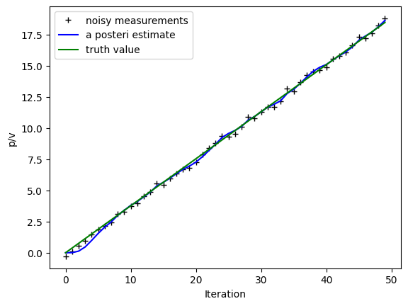

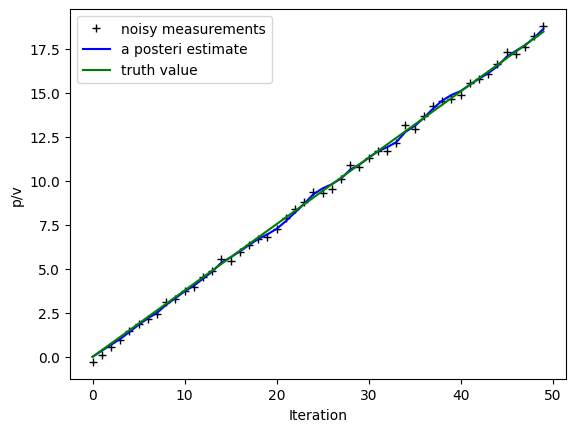

```python
Q =numpy.eye(2)*1e-5 #
R = 0.01**2 #
P[0] = numpy.zeros((2,2))

# intial guesses

# 随便给一个初值，假设速度位置都是0
xhat[0] = numpy.zeros((2,1))
kalman_filter(False)

# 给一个较为准确的初值
xhat[0] = numpy.array([[0],[0.37]])
kalman_filter(False)
```

可以发现给一个较为准确的初值后，滤波的效果明显变好。 但是即使不给一个准确的初值，kalman滤波器也能相对快速的收敛到正确的值附近。

### 2. 系统噪声Q对kalman滤波器的影响

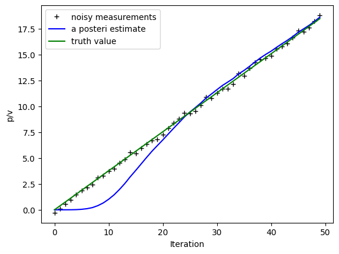

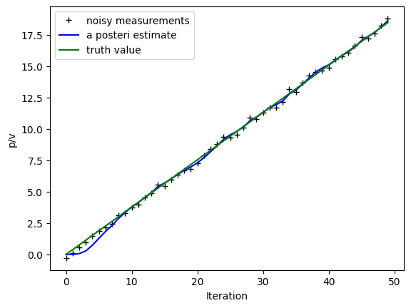

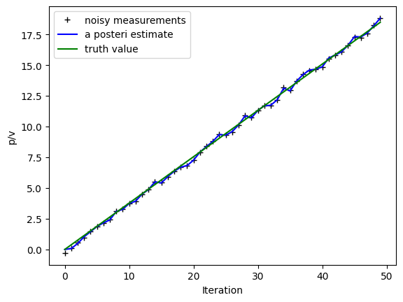

```python
R = 0.005**2 #
P[0] = numpy.zeros((2,2))
# 随便给一个初值，假设速度位置都是0
xhat[0] = numpy.zeros((2,1))

Q =numpy.eye(2)*1e-8#
kalman_filter(False)

Q =numpy.eye(2)*1e-6#
kalman_filter(False)

Q =numpy.eye(2)*1e-4#
kalman_filter(False)
```

可以发现，增大Q可以加快收敛速度，但是会发现，滤波后的值越来越接近传感器观测值了，可见是因为更加相信观测值而导致的收敛加快。

## 同时加大Q,R，并保持Q,R比值不变

```python
P[0] = numpy.zeros((2,2))
# 随便给一个初值，假设速度位置都是0
xhat[0] = numpy.zeros((2,1))

R = 2*1e-4
Q =numpy.eye(2)*1e-6#
kalman_filter(False)

R = 2*1e-3
Q =numpy.eye(2)*1e-5#
kalman_filter(False)

R = 2*1e-2
Q =numpy.eye(2)*1e-4#
kalman_filter(False)
```

[output not shown]

总结：

- Q越大，R越小，收敛越快
- R越小越相信传感器，Q越小越相信理论值
- Q,R的相对大小更重要

## 如果理论模型，即状态外推方程建模不准确，那么卡尔曼滤波器的效果会怎么样呢？

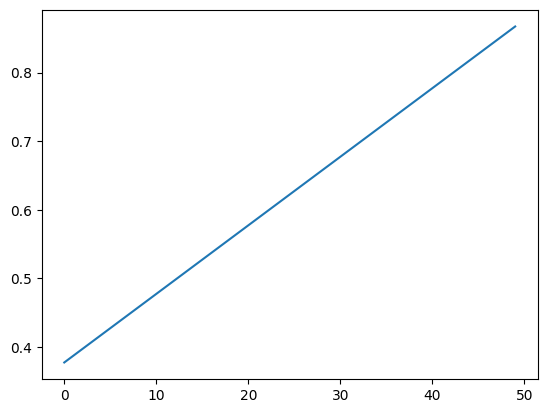

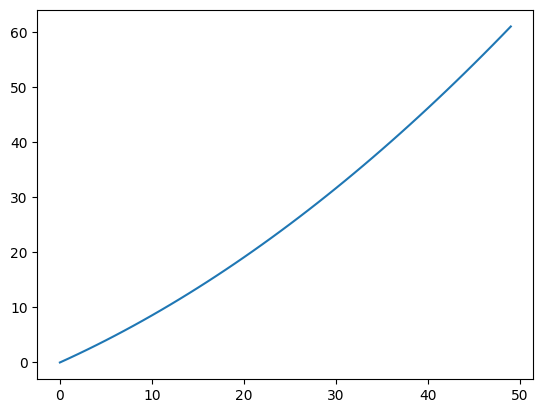

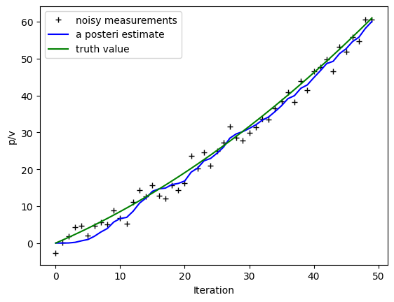

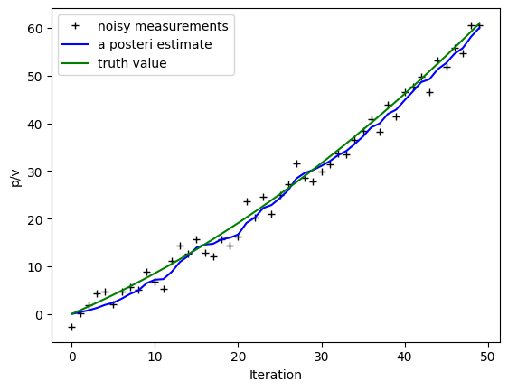

```python
# 假定物体匀加速移动，但是不修改之前的状态外推方程，依然保持匀速运动模型假设
acc=0.01
v = [0.37727+ i*acc for i in range(n_iter)] # 真实速度
p=[ (i**2-v[0]**2)/acc for i in v]

plt.figure()
plt.plot(range(n_iter),v,label='speed')
plt.figure()
plt.plot(range(n_iter),p,label='location')

z = numpy.random.normal(p,2,size=n_iter) # 观测值 ,观测时存在噪声
# 随便给一个初值，假设速度位置都是0
xhat[0] = numpy.zeros((2,1))
kalman_filter(False)

# 给一个较为准确的初值
xhat[0] = numpy.array([[0],[0.37]])
kalman_filter(False)
```

好像效果还不错，但是可以发现滤波值很接近观测值，是不是因为太相信观测值所以导致看起来还不错的那？

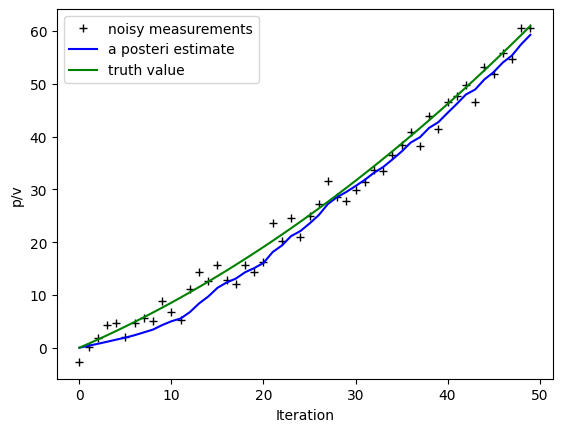

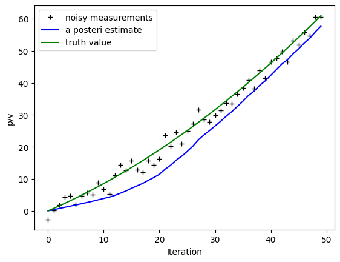

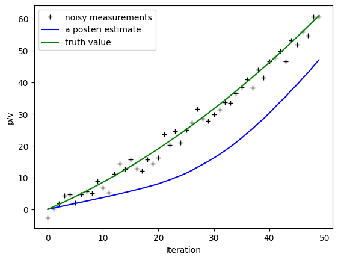

```python
# 给一个较为准确的初值
R = 2*1e-1# R增大一个数量级
xhat[0] = numpy.array([[0],[0.37]])
kalman_filter(False)
R = 2*1e0# R增大两个数量级
xhat[0] = numpy.array([[0],[0.37]])
kalman_filter(False)
R = 2*1e1# R增大三个数量级
xhat[0] = numpy.array([[0],[0.37]])
kalman_filter(False)
```

## 为什么？

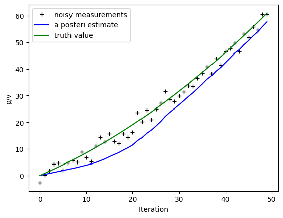

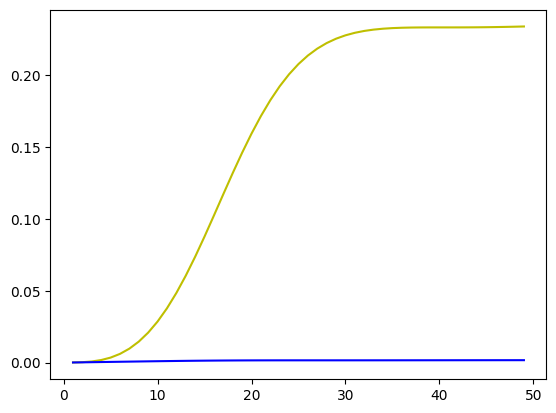

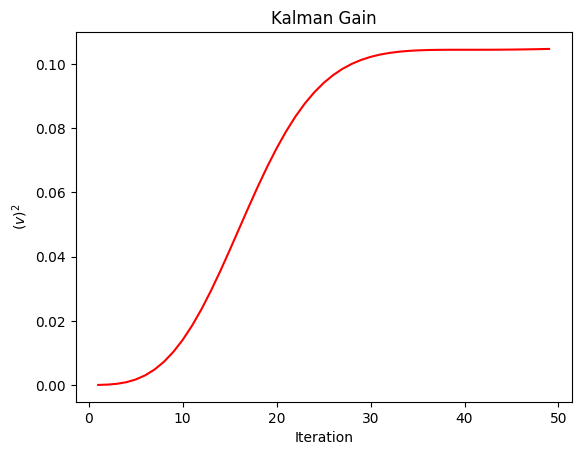

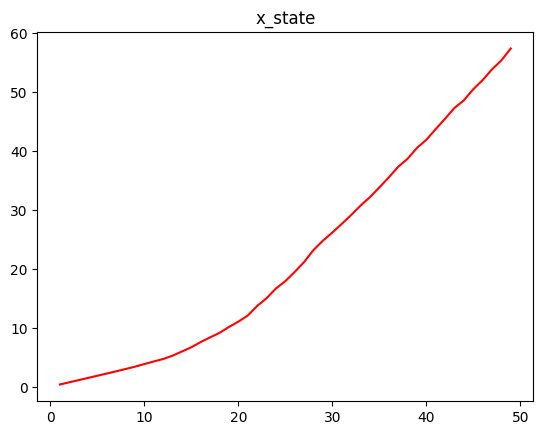

```python
# 观察一下，协方差矩阵P的变化情况
R = 2*1e0# R增大两个数量级
kalman_filter(True)

# 黄色是位置协方差，蓝色是速度协方差，红色是kalman增益
```

## 如果不是匀加速，而是时快时慢那？

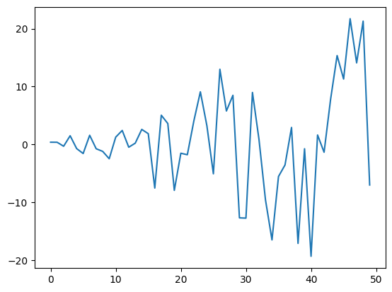

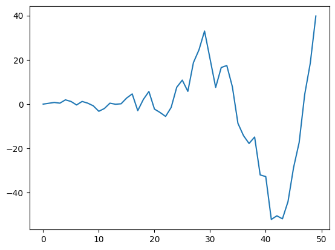

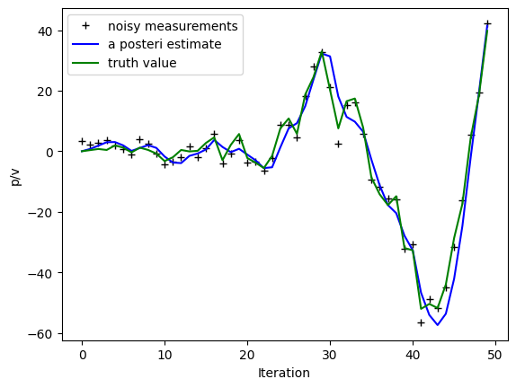

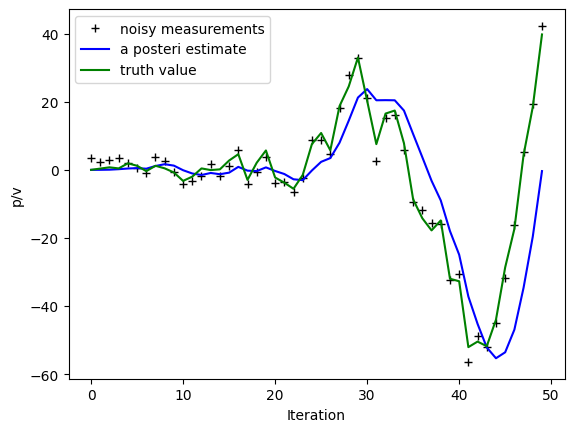

```python
# 假定物体匀加速移动，但是不修改之前的状态外推方程，依然保持匀速运动模型假设
import random

v = [0.37727+ i*(random.random()-0.5) for i in range(n_iter)] # 每一时刻的速度引入了-0.5~0.5的随机加速度
p=[0]
for i in range(len(v)-1):
    p.append(p[-1]+v[i])
plt.figure()
plt.plot(range(n_iter),v,label='speed')
plt.figure()
plt.plot(range(n_iter),p,label='location')

z = numpy.random.normal(p,2,size=n_iter) # 观测值 ,观测时存在噪声
# 随便给一个初值，假设速度位置都是0
R = 2*1e-4# R恢复正常
xhat[0] = numpy.zeros((2,1))
kalman_filter(False)

R = 2*1e-2# R增大两个数量级
xhat[0] = numpy.zeros((2,1))
kalman_filter(False)
```

## 那就是观测器对滤波效果很重要，尝试引入一个有恒定误差的观测器！

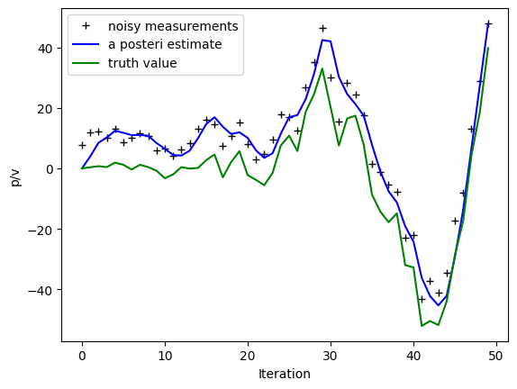

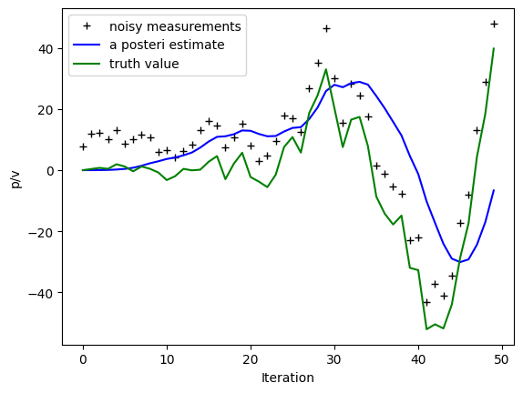

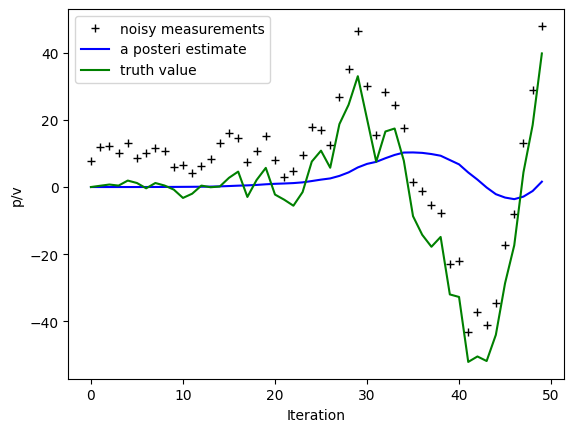

```python
z = numpy.random.normal(p,2,size=n_iter)+10 # 观测值 ,观测时位置存在10的恒定误差
# 随便给一个初值，假设速度位置都是0
R = 2*1e-4# R恢复正常
xhat[0] = numpy.zeros((2,1))
kalman_filter(False)

R = 2*1e-1# R扩大两个数量级
xhat[0] = numpy.zeros((2,1))
kalman_filter(False)

R = 2*1e1# R扩大两个数量级
xhat[0] = numpy.zeros((2,1))
kalman_filter(False)
```

可以发现观测器如果不够强大，那么融合值确实会不靠谱，上面后续两张图，随着R的不断变大，恒速运动模型渐渐发挥出了他的'误导作用'，曲线变得越来越平滑，因为假设是恒速的，所以肯定会出现曲线平滑的现象。

总结：上述例子太极端了，运动模型建错了，观测器还不靠谱，那么最后得到的结果能靠谱就怪了，最后再试试一个建模建对了，但是观测器不靠谱的情况。

## 假设运动模型建立正确，但是观测器很不靠谱

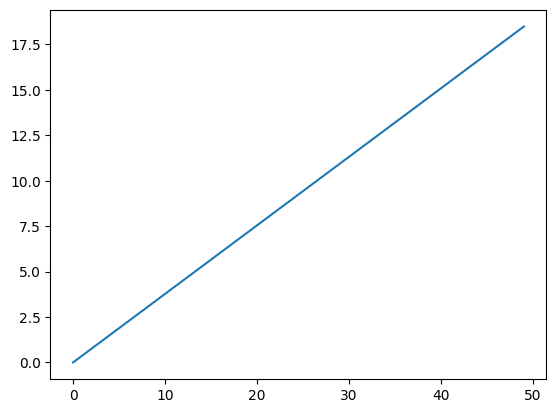

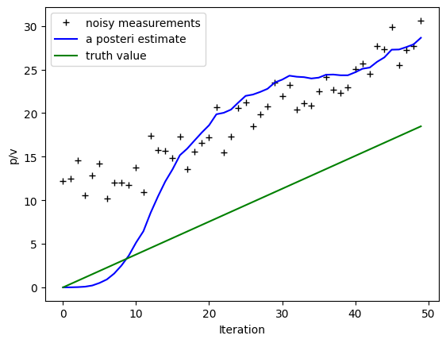

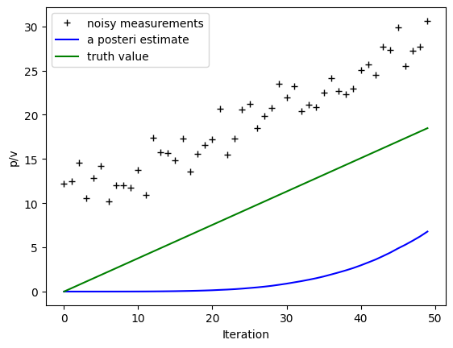

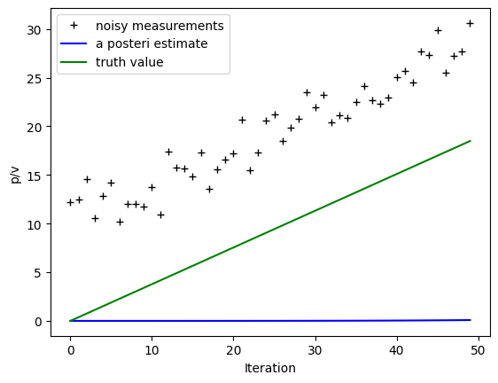

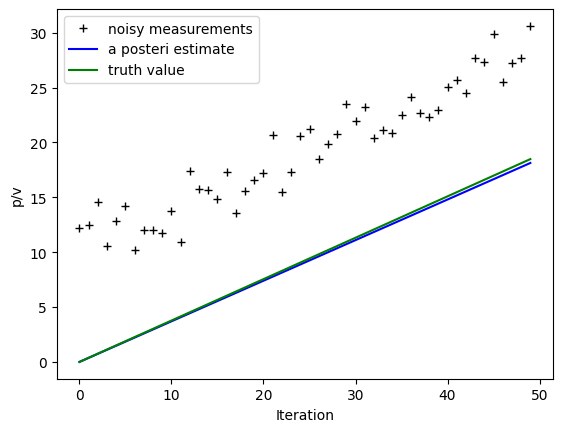

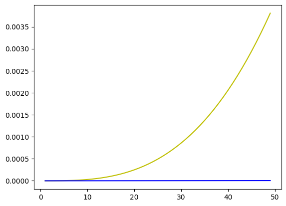

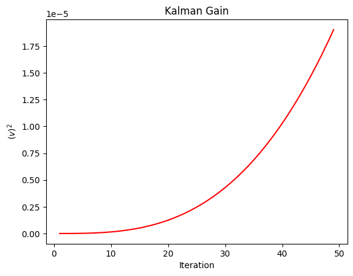

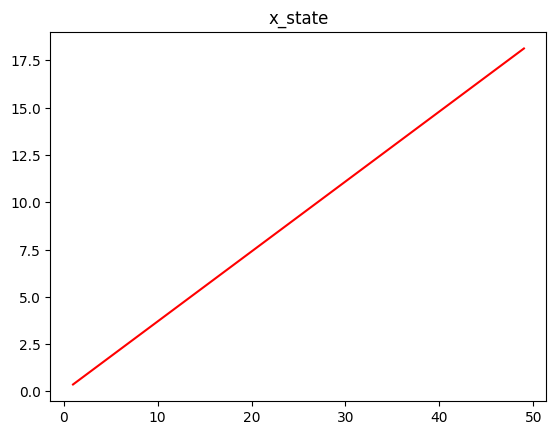

```python
v = 0.37727 # 恢复为恒速运动
p=[0]
for i in range(n_iter-1):
    p.append(p[-1]+v)

plt.figure()
plt.plot(range(n_iter),p,label='location')

z = numpy.random.normal(p,2,size=n_iter)+10 # 观测值 ,位置观测存在恒定为10的误差
# 随便给一个初值，假设速度位置都是0
R = 2*1e-4# R恢复正常
xhat[0] = numpy.zeros((2,1))
kalman_filter(False)

R = 2*1e-1# R恢复正常
xhat[0] = numpy.zeros((2,1))
kalman_filter(False)

R = 2*1e1# R恢复正常
xhat[0] = numpy.zeros((2,1))
kalman_filter(False)

Q =numpy.eye(2)*1e-7# 增大R的同时，减小Q
R = 2*1e2# R恢复正常
xhat[0] = numpy.array([[0],[0.37]])
kalman_filter(True)
```

第一张图为匀速增加的位移，后续两张图可以发现，如果观测器不靠谱，即使R给的很大，滤波效果也会很差，在后面的两张图可以看到，当观测器很差的时候，如果增大R，减小Q，使kalman filter 更加相信理论值，那么就需要初始状态较为准确，因为理论值是基于初始状态进行迭代更新的，如果初始状态不准确，那么理论值也不行了！